# Replication Report on Enos (2014)

David Kane

## Abstract

# A Unfied Measure of Changes in Exclusionary Attitudes

I construct a unified measure of the change in exclusionary attitudes by combining the results for the three questions asked in Enos (2014). Those questions were:

- Do you think the number of immigrants from Mexico whoare permitted to come to the United States to live should beincreased, left the same, or decreased?
- Would you favor allowing persons that have immigrated tothe United States illegally to remain in the country if they areemployed and have no criminal history?
- Some people favor a state law declaring English as theOfficial Language. Some other people oppose such a law.Would you favor such a law?”

Answers were on a 1 to 5 scale, with higher values corresponding to more exclusionary attitudes. Each participant answered these questions both at the start and end of the experiment. Enos (2014) looked at the (normalized) change in values for each question separately. I, instead, combine the raw changes for all three into a unified measure which ranges from -4 to 6, with positive values indicating an increase in exclusionary attitudes.

## Basic Linear Model

The following table is meant to demonstrate the robustness of the findings with an alternative meausre of the outcome, and to demonstrate that this new measure of attitude change is a potentially valid measure. In this case, rather than looking at each survey question indivually, they are combined into one index of overall attitude change. All columns report results from linear regression models with a variety of different covariates. Notice indicators of significance have been changed from the stargazer default.

[output not shown]

## Linear Model with Interaction Terms

The next table still uses linear regression, but now we include some interaction terms to see how this affects the models. Notice the first interaction term in column 1, Platform*10-day, is the **change in the effect on overall attitude change** (rather than just the effect) of waiting on the platform for those who were surveyed 10 days after the treatment, or vice versa. The coefficient for Platform now indicates the effect of waiting on the platform when 10-day is 0 or false, so being surveyed after 3 days, and the coefficient for 10-day indicates the effect of being surveyed 10 days after treatment when platform is 0 or false, so those who waited in their cars. This interpretation can be applied to the Platform*Franklin interaction in column 2 as these are both dummy variables as well. For column 3, we have a dummy (White) interacted with a continuous variable (Income). The non-interaction effects are the same as above, the effect of white when income is 0, and the effect of income when not white. The interaction can be interpreted as the change in the effect of income on overall attitude change between those who are white and not white, or as the change in the effect of being white on overall attitude given a 1 dollar increase in income.

|  | *Dependent variable:* |  |  |
| --- | --- | --- | --- |
|  | Overall Attitude Change |  |  |
|  | (1) | (2) | (3) |
| Treatment | 0.849** | 0.784** | 0.656* |
|  | (0.262) | (0.265) | (0.266) |
| Platform | 0.751 | 0.541 |  |
|  | (0.560) | (0.726) |  |
| 10-day | -1.488 |  |  |
|  | (0.960) |  |  |
| Platform*10-day | 1.494 |  |  |
|  | (0.999) |  |  |
| Franklin Line |  | -1.090 |  |
|  |  | (0.906) |  |
| Platform*Franklin |  | 1.093 |  |
|  |  | (0.950) |  |
| White |  |  | -1.431 |
|  |  |  | (0.929) |
| Income |  |  | -0.00001 |
|  |  |  | (0.00001) |
| White:Income |  |  | 0.00000 |
|  |  |  | (0.00001) |
| Intercept | -1.078* | -0.838 | 1.455 |
|  | (0.536) | (0.725) | (0.911) |
| Observations | 115 | 115 | 115 |
| R<sup>2</sup> | 0.145 | 0.137 | 0.140 |
| Adjusted R<sup>2</sup> | 0.114 | 0.106 | 0.108 |
| Residual Std. Error (df = 110) | 1.388 | 1.394 | 1.392 |
| F Statistic (df = 4; 110) | 4.650** | 4.376** | 4.462** |
| *Note:* | p<0.05; p<0.01; p<0.001 |  |  |
|  | All coefficients reported above are OLS coefficients. Positive numbers indicate more conservative responses. |  |  |

## Simple Bayesian Model

Now we will fit a simple stan_glm model where only the treatment indicator is used as a predictor. The resulting histograms show the posterior distribution for the intercept and treatment for all chains. Notice how we are no longer given a point estimate as with traditional linear regression, but a distribution of many estimates of which we take the mean.

```
##                   mean     se_mean        sd       2.5%        50%
## (Intercept) -0.4033242 0.002780820 0.1755898 -0.7456721 -0.4013719
## treatment    0.7911730 0.004280134 0.2692115  0.2703835  0.7863270
##                   97.5%
## (Intercept) -0.05663869
## treatment    1.32393213
```

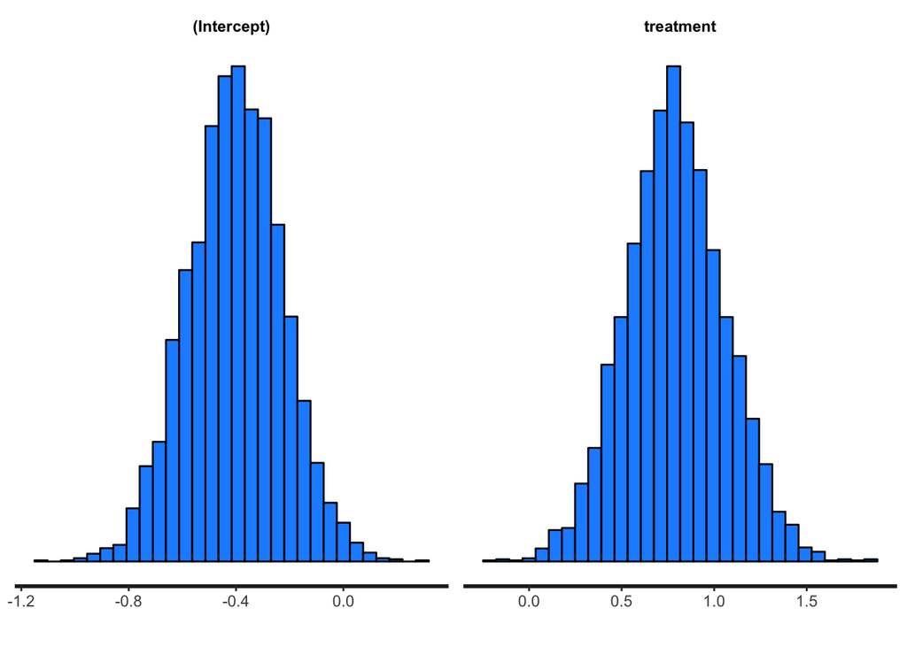

```
## stan_lmer
##  family:       gaussian [identity]
##  formula:      all_chg ~ treatment + (1 | station)
##  observations: 115
## ------
##             Median MAD_SD
## (Intercept) -0.4    0.2
## treatment    0.8    0.3
##
## Auxiliary parameter(s):
##       Median MAD_SD
## sigma 1.4    0.1
##
## Error terms:
##  Groups   Name        Std.Dev.
##  station  (Intercept) 0.24
##  Residual             1.43
## Num. levels: station 9
##
## Sample avg. posterior predictive distribution of y:
##          Median MAD_SD
## mean_PPD -0.1    0.2
##
## ------
## * For help interpreting the printed output see ?print.stanreg
## * For info on the priors used see ?prior_summary.stanreg
```

```
## 'pars' not specified. Showing first 10 parameters by default.
```

```
## ci_level: 0.8 (80% intervals)
```

```
## outer_level: 0.95 (95% intervals)
```

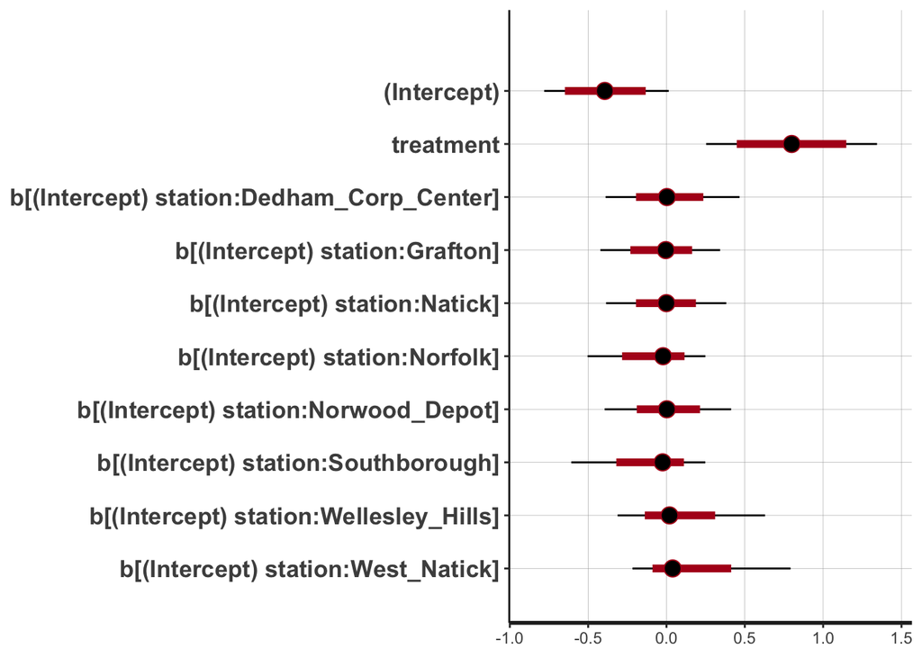

[figure not shown]

Blue line indicates complete-pooling, red line indicates no pooling, and purple dotted line indicates partial pooling estimates. Notice how stations with small sample sizes have non-pooled estimates that deviate from the complete pool estimates, but then the partial pooled estimate says “wait a second, you have a sall sample size, I don’t trust how much this estimate deviates from the pooled data,” so then the partially pooled estimate is brought closser to the blue line.

```
## stan_lmer
##  family:       gaussian [identity]
##  formula:      all_chg ~ treatment + (treatment | station)
##  observations: 115
## ------
##             Median MAD_SD
## (Intercept) -0.4    0.2
## treatment    0.9    0.3
##
## Auxiliary parameter(s):
##       Median MAD_SD
## sigma 1.4    0.1
##
## Error terms:
##  Groups   Name        Std.Dev. Corr
##  station  (Intercept) 0.31
##           treatment   0.68     -0.30
##  Residual             1.40
## Num. levels: station 9
##
## Sample avg. posterior predictive distribution of y:
##          Median MAD_SD
## mean_PPD -0.1    0.2
##
## ------
## * For help interpreting the printed output see ?print.stanreg
## * For info on the priors used see ?prior_summary.stanreg
```

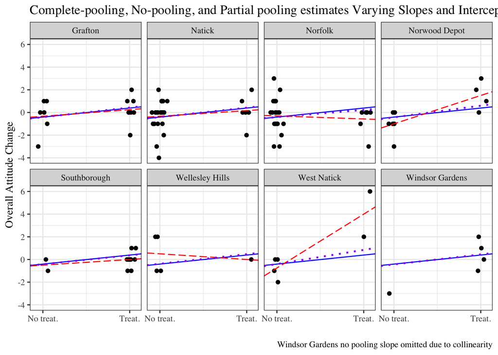

Now we allow the intercepts and the effect of treatment i.e., the slope, vary by station for the red and purple lines. Notice how some stations actually exhibit a negative effect of treatment for the no pooling model, but the partial pooling model brings these estimates back toward the blue line when considering the sample size within each station. Also notice how if the effect is quite drastic, as it is for West Natick, the partial pooling estimate will deviate more from the blue line (complete pooling). We a similar effect at Norfolk Station, but this time due to sample size rather than effect size.

# Appendix

## Table 1. Experiment results

I am able to replicate all the numbers from Table 1. One clarification is that the values for *n* are somewhat misleading. *n* varies across the questions. For example, *n* for the question about “English as official language?” is 109, as stated. But the *n* for “Number of immigrants be increased” is only 106. It is, obviously, sloppy to list a single *n* when, in fact, *n* varies across questions. The same issue arises with regard to the subset of commuters who wait in the platform. The *n* for “Number of immigrants be increased” is only 98, as compared to the stated 100 for the other two questions. This is a minor point with no meaningful implication for the results.

| Table 1. Experiment results | Table 1. Experiment results | Table 1. Experiment results | Table 1. Experiment results |
| --- | --- | --- | --- |
| Question | All respondents |  | Waits on platform |
|  | T1 levels (SD) | ATE (P)* | CATE (P) |
| Number of immigrants be increased?† | 0.489 (0.272) | 0.09 (0.008) | 0.083 (0.012) |
| Children of undocumented be allowed to stay? | 0.441 (0.362) | 0.073 (0.016) | 0.098 (0.016) |
| English as official language? | 0.619 (0.364) | 0.03 (0.27) | 0.043 (0.152) |
| n | 109 | 109 | 100 |

## Table 2

I am able to replicate almost all the values for Table 2. The biggest discrepancy is that I do not know where the values for $n$ come from. The raw data only has 123 observations, so how can we possibly have 117 control and 103 treated, as the published results claim? It looks like, from Table 3, that these are the numbers of control/treated who returned the first survey. Yet that is not the relevant $n$ for Table 2. All my other numbers match, except for income, but, even there, my results are very close to those published.

| Table 2. Covariate balance across treatment conditions | Table 2. Covariate balance across treatment conditions | Table 2. Covariate balance across treatment conditions | Table 2. Covariate balance across treatment conditions | Table 2. Covariate balance across treatment conditions |
| --- | --- | --- | --- | --- |
| Condition | Control | Treatment | Standard difference* | Z Score |
| Liberal† | 0.47 | 0.47 | 0.01 | 0.03 |
| Republican | 0.17 | 0.19 | 0.05 | 0.24 |
| Obama disapprove | 0.27 | 0.29 | 0.05 | 0.24 |
| Ride MBTA every day | 0.85 | 0.90 | 0.15 | 0.72 |
| Voted 2010 | 0.77 | 0.66 | -0.24 | -1.12 |
| Romney voter | 0.24 | 0.22 | -0.07 | -0.34 |
| Hispanic threat | 0.06 | 0.05 | -0.07 | -0.33 |
| Age | 44.66 | 40.43 | -0.35 | -1.63 |
| Residency year | 8.22 | 7.07 | -0.19 | -0.91 |
| College | 0.89 | 0.86 | -0.06 | -0.30 |
| Male | 0.60 | 0.60 | -0.01 | -0.03 |
| Hispanic | 0.03 | 0.05 | 0.11 | 0.58 |
| White | 0.91 | 0.83 | -0.24 | -1.25 |
| Income | 144,724 | 138,094 | -0.09 | -0.44 |
| n | 68 | 55 |  |  |

* Difference in standardized units. *†* Mean response values for the pretreatment variables accounting for stratification into train stations. All variables are 0 and 1 variables, except for Hispanic threat, which is a seven-point scale indicating how threatening respondents find Hispanics, recoded 0–1; residency, which is measured in years; and income, which is annual income in dollars.

## Figure 2

I can replicate Figure 2.

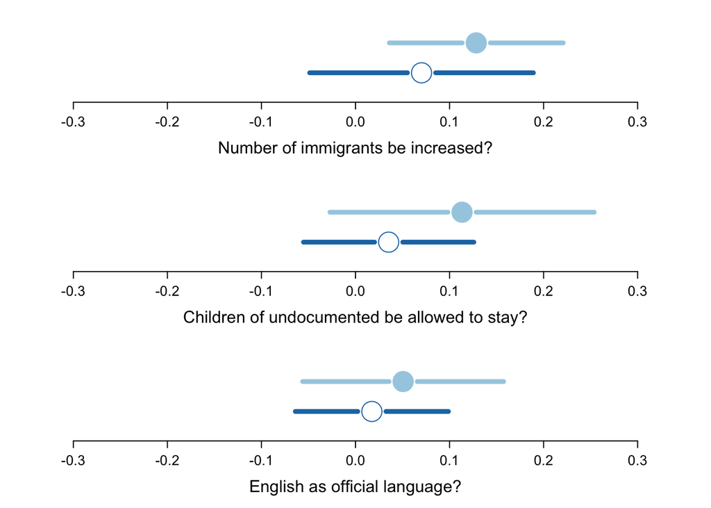

Fig. 2. Time effects. ATE and 95% confidence intervals for 3-d treatment (solid circle) and 10-d treatment (open circle). P values from top to bottom generated from a two-tailed test against the Null Hypothesis of no difference in effect between the 3-d and 10-d treatments are P = 0.195, 0.094, and 0.305. n = 55 for 3-d dose and 54 for 10-d dose. Confidence intervals are constructed by drawing the 2.5% and 97.5% quantiles from the randomized distribution.

# References

Enos, Ryan D. 2014. “Causal Effect of Intergroup Contact on Exclusionary Attitudes.” *Proceedings of the National Academy of Sciences* 111 (10). National Acad Sciences.

———. 2017. “Replication Data for: The Causal Effect of Intergroup Contact on Exclusionary Attitudes.” Harvard Dataverse. doi:10.7910/DVN/DOP4UB.